# Intrusion Detection using KDD CUP 99 Dataset

Girish Palya

## TL;DR

A group of machine learning algorithms are used to detect network intrusion (like denial-of-service (DoS) attacks) using anamolies found in [KDD CUP 99](http://kdd.ics.uci.edu/databases/kddcup99/kddcup99.html) dataset. Features are carefully extracted and performance of algorithms is compared using F1-Score.

## Dataset Description

KDD CUP 99 dataset is one of the most frequently used dataset for intrusion detection in academic literature. The dataset was originally created in 1999 at MIT’s Lincoln Laboratory during a a DARPA sponsored event, where an attack scenario to Air-Force base is simulated. First two weeks were attack free, and during the next five weeks various types of attacks were used against simulated air-force base. Resulting TCP dump files were filtered to extract features, and the resulting dataset was given to Knowledge Discovery and Data Mining (KDD) yearly competition. Dataset consists of 2 main files, one for training and another for testing.

```r
library(data.table)
train <- fread('kddcup.data', showProgress = FALSE)
# train <- fread('kddcup.data_10_percent', showProgress = FALSE)
test <- fread('kddcup.test')
col_names <- fread('kddcup.names', skip = 1, header = FALSE, sep = ':')
setnames(train, new = c(col_names[, V1], 'outcome'))
setnames(test, new = c(col_names[, V1], 'outcome'))
str(train, vec.len = 2.5)
```

```
## Classes 'data.table' and 'data.frame':   4898431 obs. of  42 variables:
##  $ duration                   : int  0 0 0 0 0 0 ...
##  $ protocol_type              : chr  "tcp" "tcp" ...
##  $ service                    : chr  "http" "http" ...
##  $ flag                       : chr  "SF" "SF" ...
##  $ src_bytes                  : int  215 162 236 233 239 238 ...
##  $ dst_bytes                  : int  45076 4528 1228 2032 486 1282 ...
##  $ land                       : int  0 0 0 0 0 0 ...
##  $ wrong_fragment             : int  0 0 0 0 0 0 ...
##  $ urgent                     : int  0 0 0 0 0 0 ...
##  $ hot                        : int  0 0 0 0 0 0 ...
##  $ num_failed_logins          : int  0 0 0 0 0 0 ...
##  $ logged_in                  : int  1 1 1 1 1 1 ...
##  $ num_compromised            : int  0 0 0 0 0 0 ...
##  $ root_shell                 : int  0 0 0 0 0 0 ...
```

[output cut: 29 more lines]

### Size

Training dataset has over 4 million observations. However, due to high redundancy(78%), only 1,074,992 are unique data points.

Test data has over 300k observations.

```r
dim(train)
```

```
## [1] 4898431      42
```

```r
train.dedup <- unique(train)
nrow(train.dedup)
```

```
## [1] 1074992
```

Test dataset has 311,029 patterns and no redundancy.

```r
dim(test)
```

```
## [1] 311029     42
```

### Features

There are 41 variables. Some of the variables are highly correlated indicating high redundancy.

```r
symbolic_vars <- c("outcome", col_names[grepl("symbolic", V2), V1])
numeric_vars <- setdiff(col_names[, V1], symbolic_vars)
correlation_matrix <- combn(numeric_vars, 2,
                            FUN = function(x)
                              c(x, cor(train[, ..x])[1L, 2L]),
                            simplify = FALSE)
correlationDF <- data.table(do.call(rbind, correlation_matrix))
correlationDF[ , correlation := round(as.numeric(V3),
                                      digits = 2)][ , V3 := NULL]
setnames(correlationDF, old = c("V1", "V2"), new = c("Var1", "Var2"))
correlationDF[order(-correlation)][1:10]
```

```
##                     Var1                     Var2 correlation
##  1:      num_compromised                 num_root        1.00
##  2:          serror_rate          srv_serror_rate        1.00
##  3:          serror_rate     dst_host_serror_rate        1.00
##  4:          serror_rate dst_host_srv_serror_rate        1.00
##  5:      srv_serror_rate     dst_host_serror_rate        1.00
##  6:      srv_serror_rate dst_host_srv_serror_rate        1.00
##  7:          rerror_rate          srv_rerror_rate        1.00
##  8: dst_host_serror_rate dst_host_srv_serror_rate        1.00
##  9:          rerror_rate     dst_host_rerror_rate        0.99
## 10:          rerror_rate dst_host_srv_rerror_rate        0.99
```

### Target classes

Dataset has five classes for output variable: Four types of attacks and a type for normal connection. Attacks are classified as follows:

- DOS: denial-of-service, e.g. syn flood;
- R2L: unauthorized access from a remote machine, e.g. guessing password;
- U2R: unauthorized access to local superuser (root) privileges, e.g., various buffer overflow attacks;
- Probing: surveillance and other types of probing, e.g., port scanning.

Each intrusion is sub-classified into specific type of attack: 24 attack types for training data, and an additional 14 types in the test data only. Further, test data is not from the same probability distribution as the training data, and it includes specific attack types not in the training data. This makes the task more realistic.

Only the sub-classes are present in the dataset. Main attack classes have to be derived and encoded into the data frame.

```r
DoS <- c("back", "land", "neptune", "pod", "smurf", "teardrop",
         "apache2", "udpstorm", "processtable", "worm", "mailbomb")
Probe <- c("satan", "ipsweep", "nmap", "portsweep", "mscan", "saint")
R2L <- c("guess_passwd", "ftp_write", "imap", "phf", "multihop",
         "warezmaster", "xsnoop", "xlock", "snmpguess", "snmpgetattack",
         "httptunnel", "sendmail", "named", "warezclient", "spy")
U2R <- c("buffer_overflow", "loadmodule", "rootkit", "perl", "xterm",
         "sqlattack", "ps")
attack_map <- function(atype) {
  atype_ <- sub("\\.", "", atype)
  if (atype_ %in% DoS) { return("DoS") }
  if (atype_ %in% Probe) { return("Probe") }
  if (atype_ %in% R2L) { return("R2L") }
  if (atype_ %in% U2R) { return("U2R") }
  if (atype_ == "normal") { return("normal") }
  stop(paste("Unknow attack type", atype))
}
train[, outcome := sapply(outcome, attack_map)]
test[, outcome := sapply(outcome, attack_map)]
```

The patterns are highly skewed in the training dataset. From the table below it is evident that 99% of the data belongs to either the Normal or DoS categories.

```r
data.table(Class = names(table(train$outcome)),
           "Training Set" = c(table(train$outcome)))[,
              Percentage := round(`Training Set`/sum(`Training Set`)*100,
                                   digits = 3)
           ][, "Test Set" := c(table(test$outcome))
           ][, "Percentage (Test)" := round(`Test Set`/sum(`Test Set`)*100,
                                   digits = 3)][]
```

```
##     Class Training Set Percentage Test Set Percentage (Test)
## 1:    DoS      3883370     79.278   229855            73.901
## 2: normal       972781     19.859    60593            19.481
## 3:  Probe        41102      0.839     4166             1.339
## 4:    R2L         1126      0.023    16345             5.255
## 5:    U2R           52      0.001       70             0.023
```

## Data Preparation

Remove redundant rows and convert string to factors.

Keep only unique examples in training set, and remove variables that have all 0 values.

```r
# Remove redundant rows
train <- train.dedup

# Remove variables that have all 0's
stopifnot(any(train[, is_host_login == 0]))
stopifnot(any(train[, num_outbound_cmds == 0]))
train[, `:=`(is_host_login = NULL, num_outbound_cmds = NULL)]
test[, `:=`(is_host_login = NULL, num_outbound_cmds = NULL)]

# Convert strings to factors
symbolic_vars <- symbolic_vars[!(symbolic_vars %in%
                                 c("is_host_login", "num_outbound_cmds"))]
train[, (symbolic_vars) := lapply(.SD, as.factor), .SDcols = symbolic_vars]
test[, (symbolic_vars) := lapply(.SD, as.factor), .SDcols = symbolic_vars]
```

## Variable Selection using PCA

*Dimensionality reduction* is a process of reducing the dimensions of a matrix while still preserving a good amount of information. *Principal component analysis (PCA)* is a popular technique used in dimensionality reduction. The idea is as follows: We think of rows of a matrix as vectors representing points in Euclidean space. A (m x n) matrix will have m points in a n-dimensional space. We can “rotate” the axes of this space in a such a way that the first axis (“x” axis) is oriented along the direction that yields the maximum variance (“spread”) of values of the coordinates of original points. Similarly, second axis (being orthogonal to the first) is chosen in a plane that yields highest variance, and so on. If this process is repeated, we will likely hit a plateau where subsequent axes capture only a small amount of variance (“information”). We can drop these less significant axes, thereby reducing the dimensions of our matrix (and size of our dataset).

PCA is ideally suited for removing redundancy from large datasets like KDD CUP 99. Data is normalized (mean of 0 and variance of 1) before principal components are computed.

```r
# Select only numeric variables since PCA involves calculating covariance matrix
numeric_vars <- setdiff(names(train.dedup), symbolic_vars)
train.numeric <- train[, .SD, .SDcols = numeric_vars]
pca <- prcomp(train.numeric, scale = TRUE)
```

Plot percentage variance explained by each principal component. Principle components represent transformation of original data, where coordinates of points refer to the rotated axes. Direction of new axes are along the eigenvectors and thus principle components (matrix product of original inputs with eigenvectors) represent new ‘variables’ in the rotated axes.

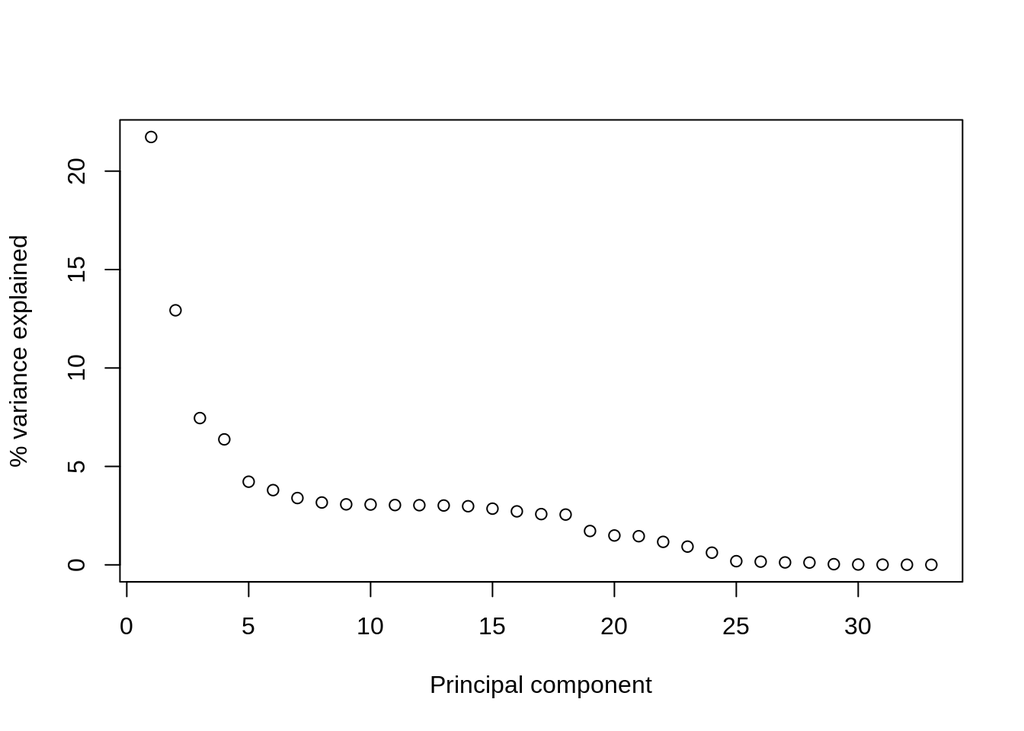

```r
pca.var <- pca$sdev^2
pca.var <- pca.var / sum(pca.var) * 100
plot(x = seq(length(pca.var)), y = pca.var, xlab = "Principal component",
     ylab = "% variance explained")
```

```r
sum(pca.var[21:33])
```

```
## [1] 4.823169
```